# Relatório de Análise de Regressão Múltipla: Fatores que Influenciam o Tempo de Viagem no Transporte Urbano

Disciplina de Estatística Aplicada

Orlando Junior, Jhonata Andrade, Arthur Coelho

24 de setembro de 2025

## **1. Introdução**

A mobilidade urbana é um tema central nas discussões sobre a qualidade de vida nas cidades. O tempo gasto em deslocamentos diários afeta diretamente a rotina, a produtividade e o bem-estar da população. Compreender os fatores que determinam a duração de uma viagem é, portanto, fundamental para o planejamento de infraestrutura, a gestão de tráfego e o desenvolvimento de políticas públicas mais eficientes.

Este relatório se propõe a analisar, por meio de técnicas de regressão linear múltipla, os principais fatores que influenciam o tempo de viagem no transporte urbano. Utilizando um conjunto de dados sobre deslocamentos, investigaremos como variáveis como a Distancia_km percorrida, o nível de Congestionamento, a ocorrência de viagens em Hora_pico, o Tipo_transporte utilizado e outras condições adversas, como Chuva_mm e a Ocorrencia_acidente, se relacionam com a variável dependente Tempo_viagem. O objetivo final é construir um modelo estatístico capaz de explicar e prever a duração dos percursos, quantificando o impacto de cada um desses fatores.

## **2. Descrição da Base de Dados**

A análise será realizada sobre a base de dados “Transporte Urbano”, que visa estudar os fatores que influenciam o tempo de deslocamento. Os dados estão organizados em uma subpasta chamada data para manter o projeto organizado.

A base de dados é composta por 1.100 observações (viagens) e 11 variáveis, que são descritas a seguir:

- Tempo_viagem: Tempo total gasto na viagem (em minutos).
- Distancia_km: Distância total do percurso (em quilômetros).
- Velocidade_media_kmh: Velocidade média desenvolvida durante a viagem (em km/h).
- Congestionamento: Nível de congestionamento em uma escala (ex: de 0 a 10).
- Hora_pico: Variável categórica que indica se a viagem ocorreu em horário de pico (Sim ou Não).
- Tipo_transporte: Meio de transporte utilizado na viagem (Ônibus, Metrô, etc.).
- Paradas_intermediarias: Número de paradas realizadas durante o trajeto.
- Chuva_mm: Volume de precipitação de chuva durante a viagem (em milímetros).
- Dia_semana: Dia da semana em que a viagem foi realizada.
- Ocorrencia_acidente: Variável categórica que indica se houve um acidente na rota (Sim ou Não).
- Tempo_espera: Tempo de espera pelo transporte (em minutos).

A seguir, apresentamos a estrutura técnica dos dados carregados no ambiente R para verificação dos tipos de cada variável.

```r
library(readxl)
library(dplyr)

dados <- read_excel("Transporte_Urbano.xlsx")

glimpse(dados)
```

```
## Rows: 1,100
## Columns: 11
## $ Tempo_viagem           <dbl> 10.98, 50.10, 41.50, 37.18, 36.79, 10.47, 53.12…
## $ Distancia_km           <dbl> 0.95, 6.31, 4.75, 1.56, 7.11, 4.26, 7.45, 7.94,…
## $ Velocidade_media_kmh   <dbl> 35.38, 25.66, 33.08, 22.95, 26.78, 35.12, 23.89…
## $ Congestionamento       <dbl> 3.16, 5.11, 3.51, 5.79, 4.85, 2.34, 5.72, 7.93,…
## $ Hora_pico              <chr> "Não", "Sim", "Não", "Não", "Não", "Não", "Sim"…
## $ Tipo_transporte        <chr> "Ônibus", "Ônibus", "Ônibus", "Bicicleta", "Met…
## $ Paradas_intermediarias <dbl> 1, 3, 2, 1, 1, 2, 1, 5, 2, 3, 7, 0, 6, 1, 5, 2,…
## $ Chuva_mm               <dbl> 2.27, 0.00, 2.50, 6.32, 0.00, 0.00, 0.00, 4.05,…
## $ Dia_semana             <chr> "Seg", "Qua", "Sex", "Ter", "Ter", "Qui", "Qua"…
## $ Ocorrencia_acidente    <chr> "Não", "Não", "Não", "Não", "Não", "Não", "Não"…
## $ Tempo_espera           <dbl> 9.79, 15.03, 12.71, 7.78, 7.85, 8.32, 15.94, 18…
```

## **3. Análise Exploratória de Dados**

Nesta seção, realizaremos uma análise exploratória para compreender as características fundamentais do nosso conjunto de dados. O objetivo é verificar a consistência dos dados, identificar a presença de valores ausentes e outliers, e analisar a distribuição das variáveis que podem influenciar o tempo de viagem.

### **3.1 Investigação de Dados Ausentes**

A primeira etapa da análise de consistência é verificar a presença de dados ausentes (também conhecidos como `NA` ou *missing values*). Para isso, utilizamos um conjunto de funções que nos permitem quantificar e visualizar esses dados.

```
##           Tempo_viagem           Distancia_km   Velocidade_media_kmh
##                      0                     11                     11
##       Congestionamento              Hora_pico        Tipo_transporte
##                     11                      0                      0
## Paradas_intermediarias               Chuva_mm             Dia_semana
##                      0                     11                      0
##    Ocorrencia_acidente           Tempo_espera
##                      0                     11
```

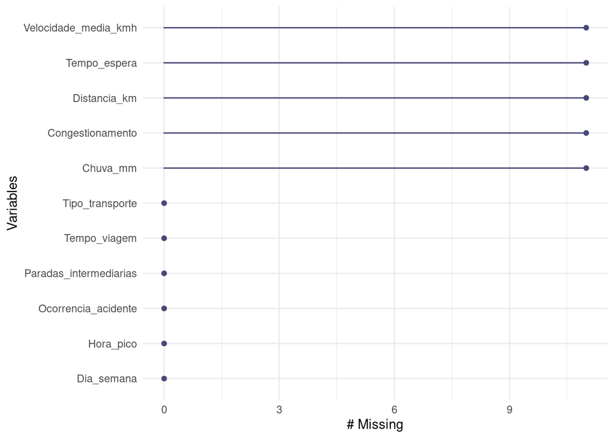

Table: Data summary

| Name | dados |
| --- | --- |
| Number of rows | 1100 |
| Number of columns | 11 |
| _______________________ |  |
| Column type frequency: |  |
| character | 4 |
| numeric | 7 |
| ________________________ |  |
| Group variables | None |

**Variable type: character**

| skim_variable | n_missing | complete_rate | min | max | empty | n_unique | whitespace |
| --- | --- | --- | --- | --- | --- | --- | --- |
| Hora_pico | 0 | 1 | 3 | 3 | 0 | 2 | 0 |
| Tipo_transporte | 0 | 1 | 5 | 9 | 0 | 4 | 0 |
| Dia_semana | 0 | 1 | 3 | 3 | 0 | 7 | 0 |
| Ocorrencia_acidente | 0 | 1 | 3 | 3 | 0 | 2 | 0 |

**Variable type: numeric**

| skim_variable | n_missing | complete_rate | mean | sd | p0 | p25 | p50 | p75 | p100 | hist |
| --- | --- | --- | --- | --- | --- | --- | --- | --- | --- | --- |
| Tempo_viagem | 0 | 1.00 | 39.22 | 19.20 | 5.00 | 25.56 | 38.33 | 52.23 | 111.38 | ▅▇▅▁▁ |
| Distancia_km | 11 | 0.99 | 7.20 | 4.64 | -4.22 | 3.88 | 6.21 | 9.43 | 32.21 | ▂▇▂▁▁ |
| Velocidade_media_kmh | 11 | 0.99 | 29.25 | 7.02 | 8.00 | 24.32 | 29.51 | 34.30 | 46.96 | ▁▃▇▇▂ |
| Congestionamento | 11 | 0.99 | 4.14 | 1.82 | 0.00 | 2.84 | 4.04 | 5.39 | 10.00 | ▂▇▇▃▁ |
| Paradas_intermediarias | 0 | 1.00 | 3.98 | 2.75 | 0.00 | 2.00 | 4.00 | 5.00 | 17.00 | ▇▆▂▁▁ |
| Chuva_mm | 11 | 0.99 | 1.71 | 2.91 | 0.00 | 0.00 | 0.00 | 2.69 | 23.72 | ▇▁▁▁▁ |
| Tempo_espera | 11 | 0.99 | 10.24 | 4.17 | -6.62 | 7.71 | 10.12 | 13.07 | 21.09 | ▁▂▇▇▂ |

**Análise dos Resultados:**

### **3.2 Correção da Base de Dados**

Abaixo, executamos o procedimento de limpeza e verificamos se a remoção foi bem-sucedida.

```r
cat("Número de linhas ANTES da limpeza:", nrow(dados), "\n")
```

```
## Número de linhas ANTES da limpeza: 1100
```

```r
dados_limpos <- na.omit(dados)
cat("Número de linhas DEPOIS da limpeza:", nrow(dados_limpos), "\n")
```

```
## Número de linhas DEPOIS da limpeza: 1047
```

```r
cat("\nVerificação de NAs após a limpeza:\n")
```

```
##
## Verificação de NAs após a limpeza:
```

```r
colSums(is.na(dados_limpos))
```

```
##           Tempo_viagem           Distancia_km   Velocidade_media_kmh
##                      0                      0                      0
##       Congestionamento              Hora_pico        Tipo_transporte
##                      0                      0                      0
## Paradas_intermediarias               Chuva_mm             Dia_semana
##                      0                      0                      0
##    Ocorrencia_acidente           Tempo_espera
##                      0                      0
```

### **3.3 Análise de Outliers e Valores Inconsistentes**

Após a limpeza dos dados ausentes, o próximo passo é investigar a presença de outliers e valores inconsistentes que possam distorcer a análise e o modelo de regressão. A forma mais eficaz de visualizar outliers é através de boxplots.

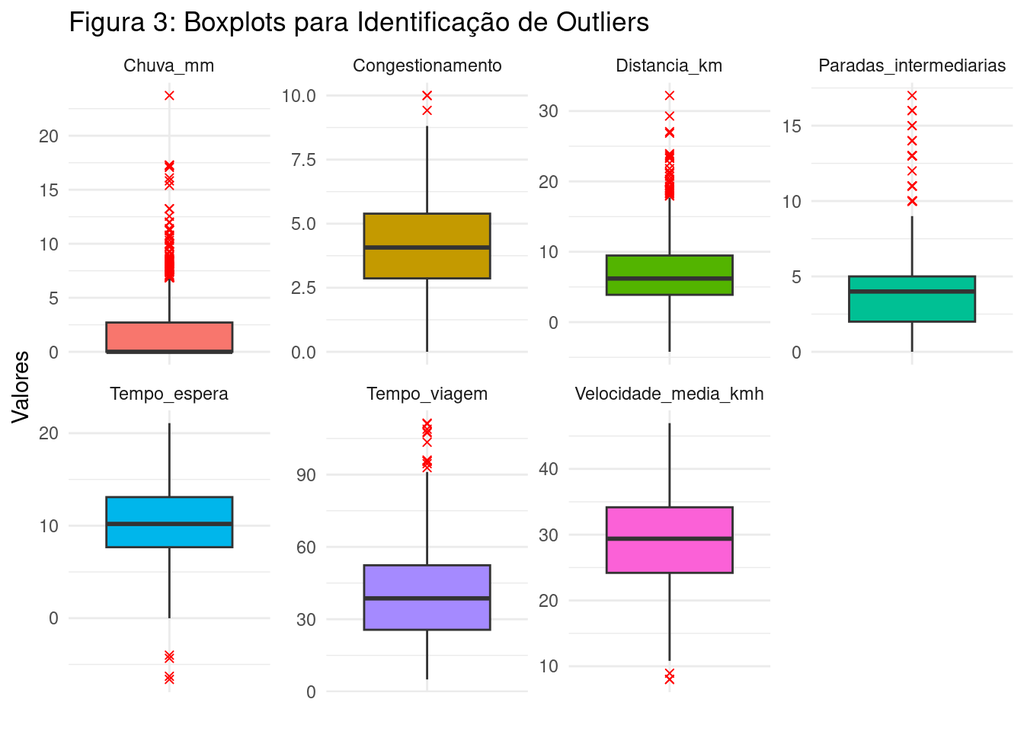

```r
# Vamos gerar os boxplots usando a base de dados limpa (sem NAs)
# para ter uma visão clara dos outliers remanescentes.
dados_limpos %>%
  select(where(is.numeric)) %>%
  tidyr::pivot_longer(everything(), names_to = "variavel", values_to = "valor") %>%
  ggplot(aes(x = variavel, y = valor, fill = variavel)) +
  geom_boxplot(outlier.colour = "red", outlier.shape = 4) +
  facet_wrap(~ variavel, scales = "free", ncol = 4) +
  labs(
    title = "Figura 3: Boxplots para Identificação de Outliers",
    x = "",
    y = "Valores"
  ) +
  theme_minimal() +
  theme(axis.text.x = element_blank(), legend.position = "none")
```

**Análise dos Resultados:**

A análise dos boxplots e da tabela de resumo estatístico (skim) revela dois problemas principais:

1. Valores Inconsistentes: Foram identificados valores mínimos negativos para Distancia_km e Tempo_espera. Como essas métricas não podem ser negativas, tratam-se de erros de entrada de dados que precisam ser corrigidos.
2. Outliers Potenciais: Diversas variáveis, como Tempo_viagem, Chuva_mm e Paradas_intermediarias, apresentam múltiplos pontos (marcados em vermelho) acima do limite superior do boxplot. Estes são outliers que, embora possam ser valores reais e possíveis (uma viagem muito longa, um dia de chuva extrema), têm o potencial de influenciar desproporcionalmente o nosso modelo.

### **3.4 Estratégia de Tratamento**

A nossa estratégia será dividida em duas etapas:

1. Correção dos Erros: Primeiro, vamos tratar os valores impossíveis (negativos), convertendo-os para NA. Em seguida, vamos reaplicar a remoção de linhas com NA para garantir que nosso dataset final não contenha esses erros.

```r
# Vamos usar o 'dados_limpos' que já não tinha os NAs originais.
# Etapa 1: Substituir valores negativos por NA
dados_corrigidos <- dados_limpos %>%
  mutate(
    Distancia_km = ifelse(Distancia_km < 0, NA, Distancia_km),
    Tempo_espera = ifelse(Tempo_espera < 0, NA, Tempo_espera)
  )

# Etapa 2: Remover as linhas que agora contêm os novos NAs
dados_final <- na.omit(dados_corrigidos)

# Verificando as dimensões dos dataframes para ver o resultado da limpeza
cat("Linhas antes da correção de erros:", nrow(dados_limpos), "\n")
```

```
## Linhas antes da correção de erros: 1047
```

```r
cat("Linhas no dataset final (pós-correção):", nrow(dados_final), "\n")
```

```
## Linhas no dataset final (pós-correção): 1038
```

- **Interpretação da Correção:** A execução do código de limpeza mostra que, partindo de um conjunto de dados com 1047 observações, um total de 9 linhas que continham valores negativos inválidos foram removidas. O nosso dataset final para análise, dados_final, agora possui 1038 observações completas e consistentes.
2. Decisão sobre os Outliers Extremos:

Para os outliers restantes (valores muito altos, mas plausíveis), a melhor prática não é removê-los imediatamente, pois eles podem representar uma variabilidade real e importante do fenômeno que estamos estudando. A remoção arbitrária poderia enviesar nosso modelo.

Portanto, manteremos esses outliers por enquanto. Na etapa de diagnóstico do modelo de regressão (Seção 7), avaliaremos a real influência desses pontos. Se for constatado que eles violam os pressupostos do modelo (por exemplo, através da análise de resíduos ou da Distância de Cook), poderemos então considerar estratégias mais avançadas, como a transformação das variáveis (ex: aplicação de logaritmo) ou a remoção justificada dos casos mais influentes.

A partir de agora, todas as análises serão feitas com o dataset dados_final.

## **4. Análises univariadas e bivariadas**

Nesta etapa, foram realizadas análises descritivas (univariadas) e exploratórias (bivariadas) com o objetivo de compreender melhor o comportamento das variáveis explicativas em relação à variável resposta **Tempo_viagem**.

### **4.1 Análise univariada**

As variáveis numéricas apresentaram os seguintes comportamentos principais:

- **Congestionamento**, **Velocidade_media_kmh**, **Tempo_espera**, **Distancia_km** e **Paradas_intermediarias** exibiram forte variabilidade, com distribuições moderadamente assimétricas e presença de outliers.
- **Chuva_mm** apresentou assimetria acentuada, com predominância de valores zero e poucos registros extremos (até 23 mm).
- **Tempo_viagem** mostrou distribuição aproximadamente normal, mas com cauda longa à direita (máximo de 111 minutos).

Esses padrões sugerem que, embora algumas variáveis numéricas apresentem valores extremos, eles são plausíveis e devem ser mantidos para preservar a variabilidade do fenômeno estudado.

```r
library(skimr)
library(ggplot2)
library(dplyr)

# Análise univariada
skim(dados_final)
```

Data summary

| Name | dados_final |
| --- | --- |
| Number of rows | 1038 |
| Number of columns | 11 |
| _______________________ |  |
| Column type frequency: |  |
| character | 4 |
| numeric | 7 |
| ________________________ |  |
| Group variables | None |

**Variable type: character**

| skim_variable | n_missing | complete_rate | min | max | empty | n_unique | whitespace |
| --- | --- | --- | --- | --- | --- | --- | --- |
| Hora_pico | 0 | 1 | 3 | 3 | 0 | 2 | 0 |
| Tipo_transporte | 0 | 1 | 5 | 9 | 0 | 4 | 0 |
| Dia_semana | 0 | 1 | 3 | 3 | 0 | 7 | 0 |
| Ocorrencia_acidente | 0 | 1 | 3 | 3 | 0 | 2 | 0 |

**Variable type: numeric**

| skim_variable | n_missing | complete_rate | mean | sd | p0 | p25 | p50 | p75 | p100 | hist |
| --- | --- | --- | --- | --- | --- | --- | --- | --- | --- | --- |
| Tempo_viagem | 0 | 1 | 39.38 | 19.33 | 5.0 | 25.56 | 38.66 | 52.39 | 111.38 | ▅▇▅▁▁ |
| Distancia_km | 0 | 1 | 7.25 | 4.61 | 0.5 | 3.89 | 6.21 | 9.51 | 32.21 | ▇▅▁▁▁ |
| Velocidade_media_kmh | 0 | 1 | 29.18 | 7.04 | 8.0 | 24.20 | 29.38 | 34.17 | 46.96 | ▁▃▇▇▂ |
| Congestionamento | 0 | 1 | 4.15 | 1.83 | 0.0 | 2.85 | 4.07 | 5.39 | 10.00 | ▂▇▇▃▁ |
| Paradas_intermediarias | 0 | 1 | 4.01 | 2.78 | 0.0 | 2.00 | 4.00 | 5.00 | 17.00 | ▇▅▂▁▁ |
| Chuva_mm | 0 | 1 | 1.74 | 2.94 | 0.0 | 0.00 | 0.00 | 2.71 | 23.72 | ▇▁▁▁▁ |
| Tempo_espera | 0 | 1 | 10.32 | 4.07 | 0.0 | 7.72 | 10.21 | 13.11 | 21.09 | ▂▅▇▅▁ |

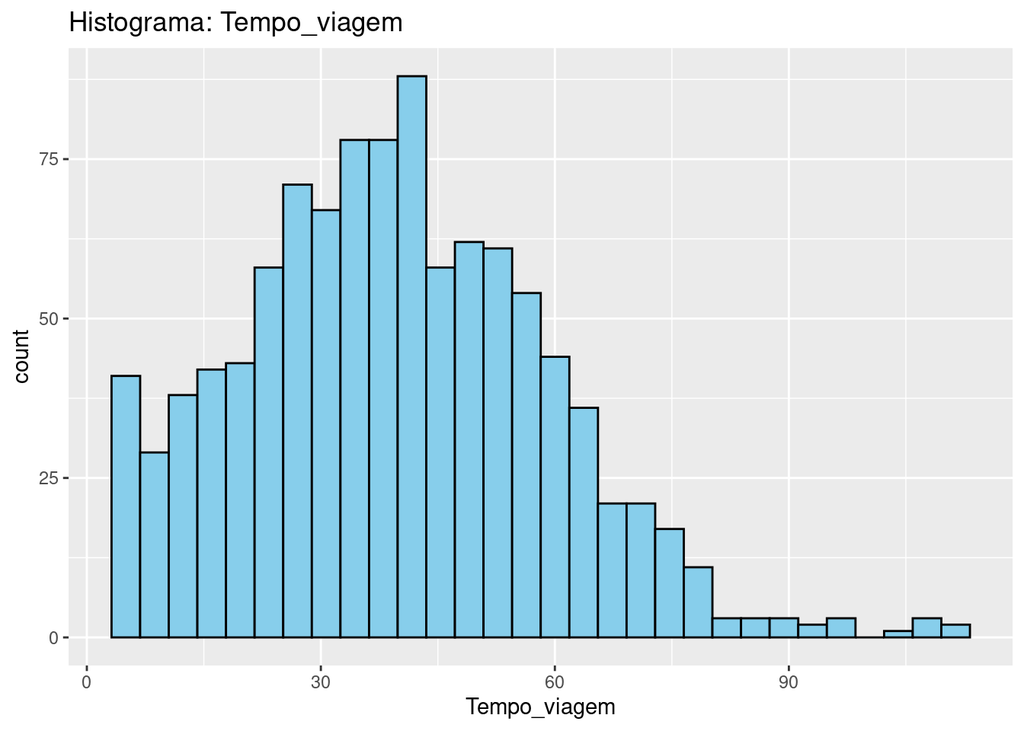

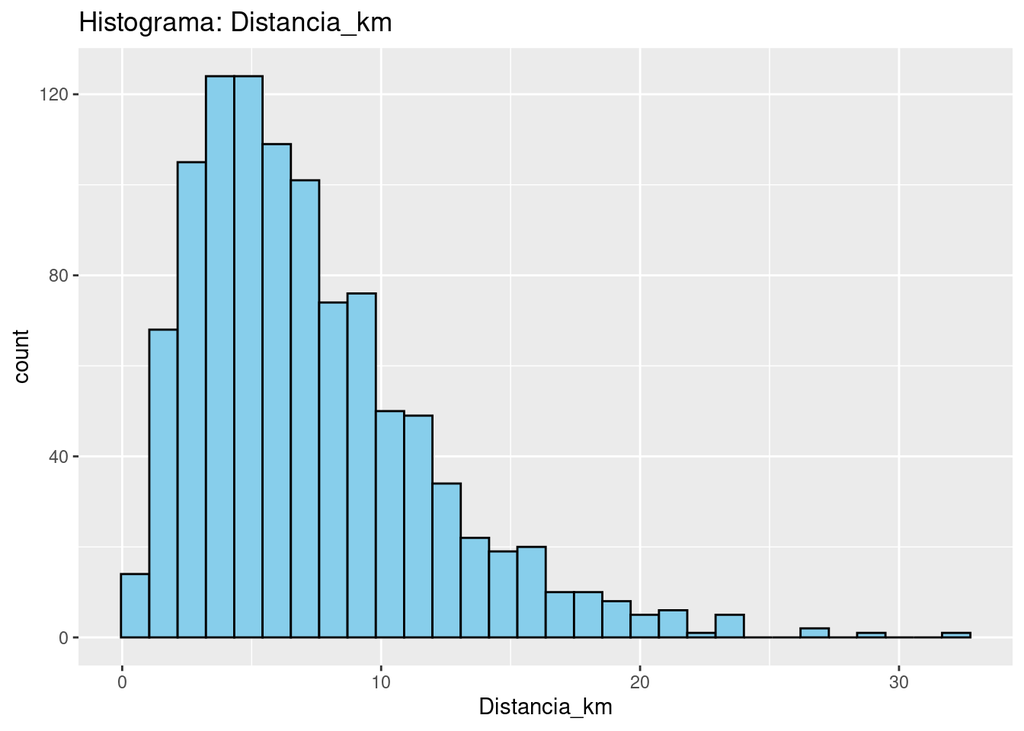

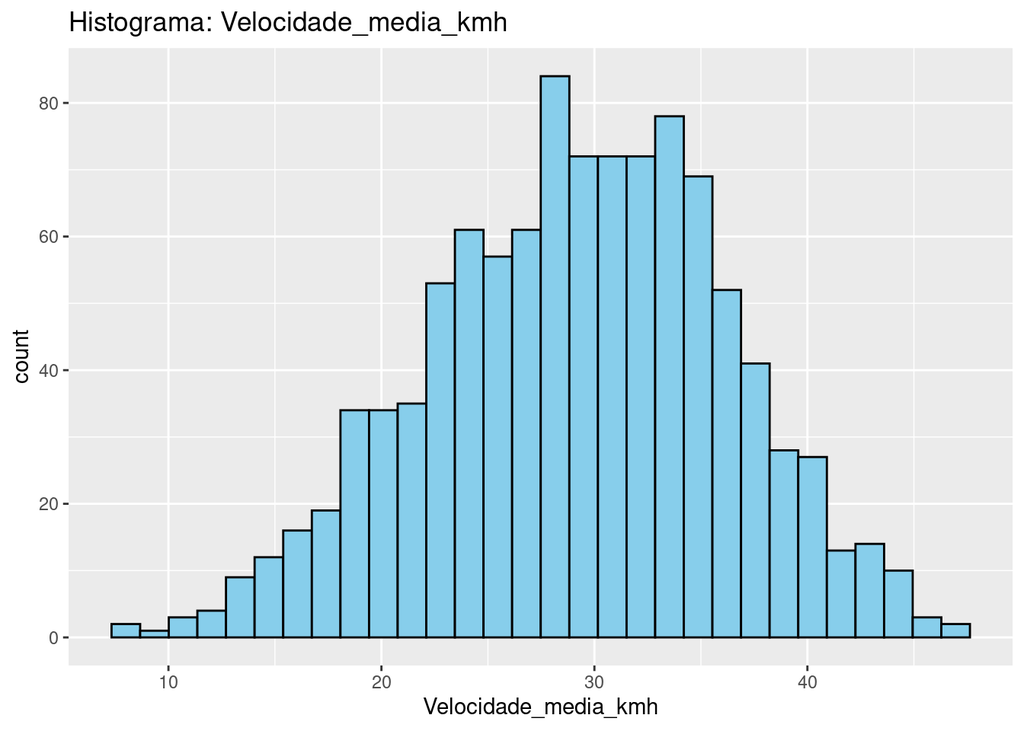

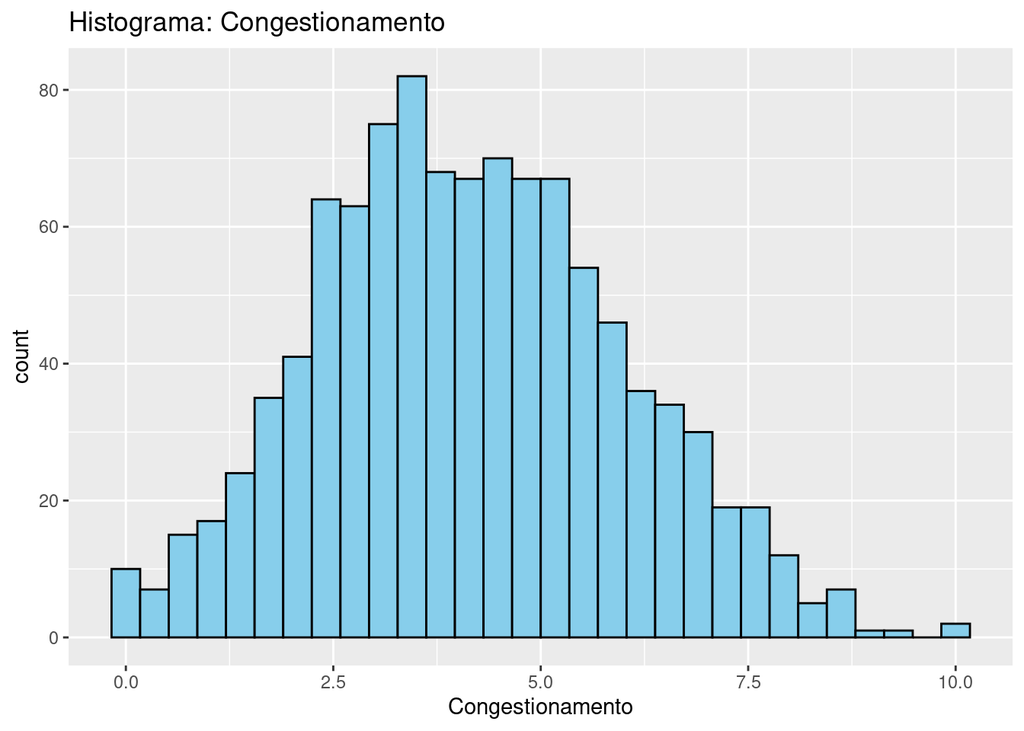

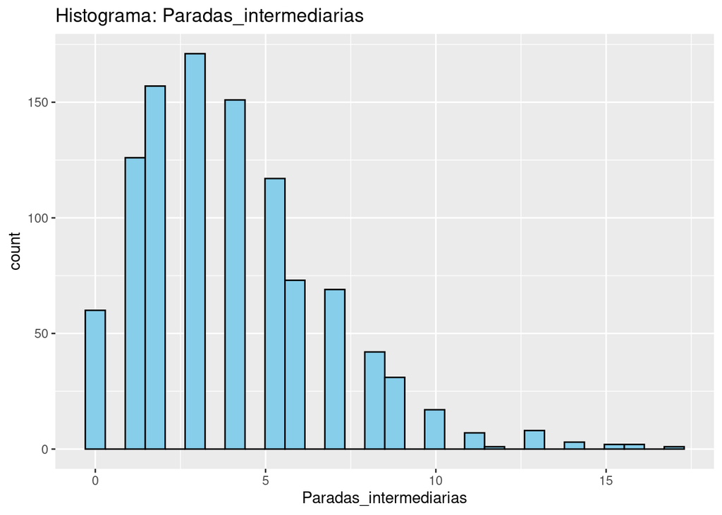

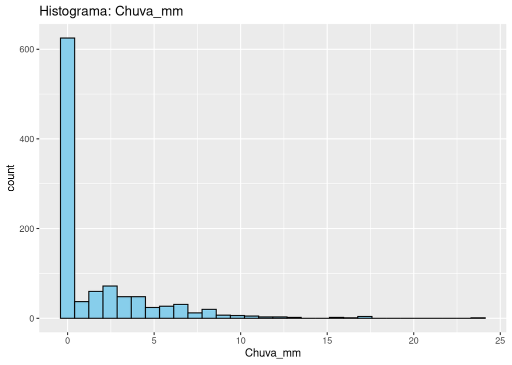

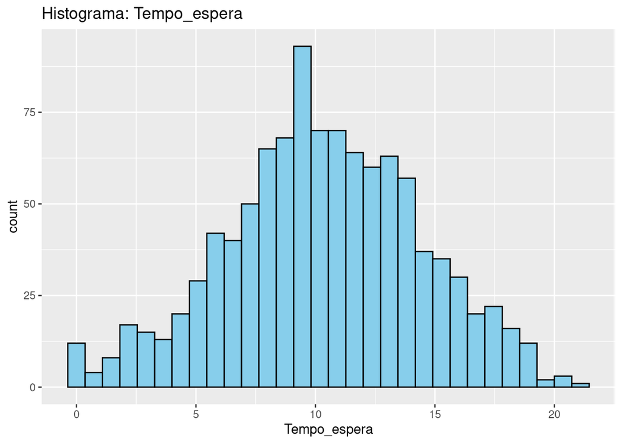

```r
# Histogramas para variáveis numéricas
num_vars <- names(dados_final %>% select(where(is.numeric)))
for(v in num_vars){
  print(
    ggplot(dados_final, aes_string(x = v)) +
      geom_histogram(bins = 30, fill = "skyblue", color = "black") +
      ggtitle(paste("Histograma:", v))
  )
}
```

### **4.2 Análise bivariada**

Foram analisadas as relações entre a variável resposta (**Tempo_viagem**) e as variáveis explicativas, tanto numéricas quanto categóricas.

#### **4.2.1 Correlações (numéricas)**

A análise de correlação de Pearson mostrou os seguintes coeficientes em relação ao **Tempo_viagem**:

- **Congestionamento**: r = 0,69 (forte e positiva)
- **Velocidade_media_kmh**: r = -0,67 (forte e negativa)
- **Tempo_espera**: r = 0,60 (forte e positiva)
- **Distancia_km**: r = 0,53 (moderada/forte e positiva)
- **Paradas_intermediarias**: r = 0,46 (moderada e positiva)
- **Chuva_mm**: r ≈ 0 (não significativa)

Esses resultados indicam risco de multicolinearidade, em especial entre variáveis ligadas ao trânsito.

```r
# Calcular a matriz de correlação
cor_matrix <- cor(dados_final %>% select(where(is.numeric)),
                  use = "complete.obs")

# Extrair correlações com a variável resposta Tempo_viagem
corr_with_response <- cor_matrix[, "Tempo_viagem", drop = FALSE]
corr_with_response <- data.frame(
  Variavel = rownames(corr_with_response),
  Correlacao = corr_with_response[, 1]
) %>%
  filter(Variavel != "Tempo_viagem") %>%  # Remover a própria variável resposta
  arrange(desc(abs(Correlacao)))

# Exibir as correlações
print(corr_with_response)
```

```
##                                      Variavel   Correlacao
## Congestionamento             Congestionamento  0.690519724
## Velocidade_media_kmh     Velocidade_media_kmh -0.672132327
## Tempo_espera                     Tempo_espera  0.601500449
## Distancia_km                     Distancia_km  0.528394319
## Paradas_intermediarias Paradas_intermediarias  0.462301462
## Chuva_mm                             Chuva_mm -0.001111525
```

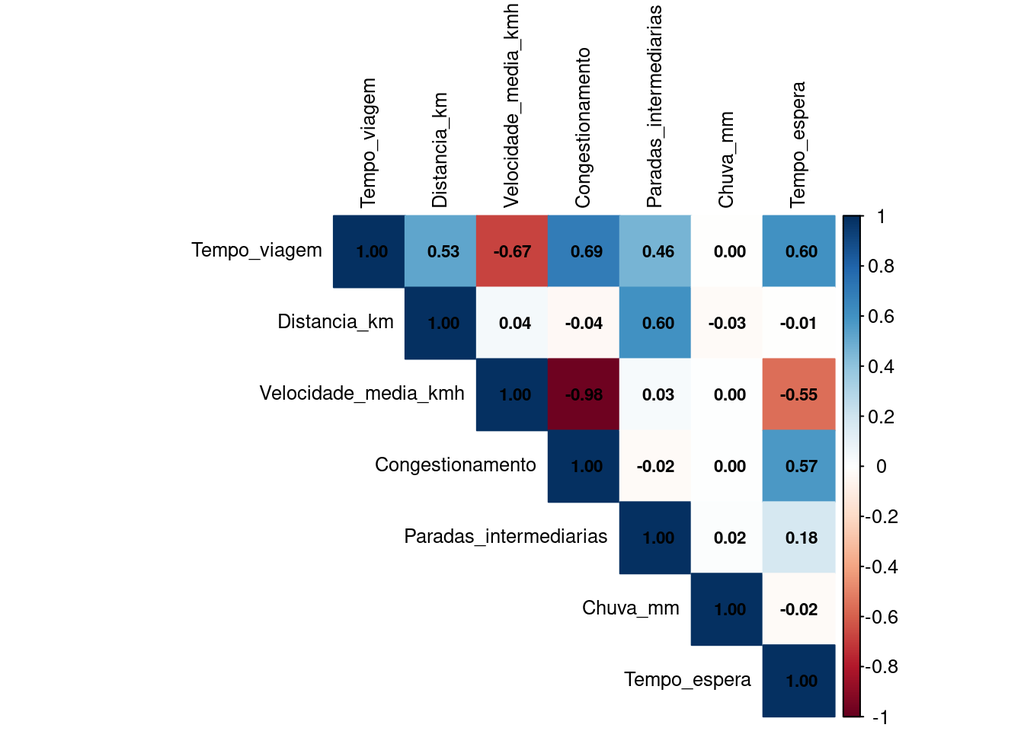

```r
# Gráfico de correlações
library(corrplot)
corrplot(cor_matrix, method = "color", type = "upper",
         addCoef.col = "black", number.cex = 0.7,
         tl.cex = 0.8, tl.col = "black")
```

### **4.3 Multicolinearidade**

A verificação por meio do Fator de Inflação da Variância (VIF) indicou valores elevados para **Congestionamento** (GVIF_adj = 5,1) e **Velocidade_media_kmh** (GVIF_adj = 4,8).  
Isso confirma a presença de multicolinearidade entre essas variáveis.

Foram então estimados dois modelos alternativos:

```r
# Verificar se os modelos já foram criados
if(!exists("model_full")) {
  # Criar modelos se não existirem
  model_full <- lm(Tempo_viagem ~ ., data = dados_final)
  model_A <- lm(Tempo_viagem ~ . - Velocidade_media_kmh, data = dados_final)
  model_B <- lm(Tempo_viagem ~ . - Congestionamento, data = dados_final)
}

# Verificar VIF e AIC
library(car)
vif_results <- vif(model_full)
print(vif_results)
```

```
##                             GVIF Df GVIF^(1/(2*Df))
## Distancia_km            1.707807  1        1.306831
## Velocidade_media_kmh   23.306212  1        4.827651
## Congestionamento       26.161973  1        5.114878
## Hora_pico               2.426225  1        1.557635
## Tipo_transporte         3.323889  3        1.221634
## Paradas_intermediarias  1.966088  1        1.402173
## Chuva_mm                1.012783  1        1.006371
## Dia_semana              1.380218  6        1.027217
## Ocorrencia_acidente     1.065838  1        1.032394
## Tempo_espera            4.476560  1        2.115788
```

```r
# Comparar AIC dos modelos
AIC_comparison <- AIC(model_A, model_B)
print(AIC_comparison)
```

```
##         df      AIC
## model_A 18 6679.175
## model_B 18 6713.847
```

- **Modelo A (com Congestionamento, sem Velocidade_media_kmh):** R² ajustado = 0,904; AIC = 6679.
- **Modelo B (com Velocidade_media_kmh, sem Congestionamento):** R² ajustado = 0,901; AIC = 6714.

O **Modelo A** apresentou melhor desempenho (maior R² ajustado e menor AIC).  
Assim, optou-se por manter **Congestionamento** como variável explicativa no modelo final, em detrimento de **Velocidade_media_kmh**.

**Interpretação final:**  
As análises univariadas e bivariadas confirmaram que o tempo de viagem é influenciado principalmente pelo nível de congestionamento, tempo de espera, distância percorrida e número de paradas intermediárias, além de fatores contextuais como ocorrência de acidentes, horário de pico, tipo de transporte e dia da semana.  
A variável **Chuva_mm** não apresentou associação significativa com a resposta.  
O problema de multicolinearidade foi resolvido mantendo apenas a variável **Congestionamento**, garantindo maior estabilidade ao modelo.

## **5. Ajuste do modelo inicial**

Nesta etapa procedeu-se ao ajuste de um modelo inicial contendo todas as variáveis explicativas disponíveis, com o objetivo de verificar o ajuste geral, identificar problemas de especificação e diagnosticar potenciais fontes de instabilidade (por exemplo, multicolinearidade).

```r
# Ajuste do modelo com todas as variáveis candidatas
model_full <- lm(Tempo_viagem ~ Distancia_km + Congestionamento + Velocidade_media_kmh +
                   Hora_pico + Tipo_transporte + Paradas_intermediarias + Chuva_mm +
                   Dia_semana + Ocorrencia_acidente + Tempo_espera,
                 data = dados_final)

# Sumário e diagnósticos iniciais
summary(model_full)
```

```
##
## Call:
## lm(formula = Tempo_viagem ~ Distancia_km + Congestionamento +
##     Velocidade_media_kmh + Hora_pico + Tipo_transporte + Paradas_intermediarias +
##     Chuva_mm + Dia_semana + Ocorrencia_acidente + Tempo_espera,
##     data = dados_final)
##
## Residuals:
##      Min       1Q   Median       3Q      Max
## -20.8463  -3.9697   0.0761   4.1228  22.0839
##
## Coefficients:
##                         Estimate Std. Error t value Pr(>|t|)
## (Intercept)              4.50385    5.77036   0.781  0.43527
## Distancia_km             2.01158    0.05259  38.249  < 2e-16 ***
## Congestionamento         3.32624    0.51889   6.410 2.22e-10 ***
## Velocidade_media_kmh    -0.31733    0.12711  -2.497  0.01270 *
## Hora_picoSim             5.04826    0.58898   8.571  < 2e-16 ***
## Tipo_transporteCarroApp -6.24807    0.90883  -6.875 1.08e-11 ***
## Tipo_transporteMetrô    -7.84424    0.76750 -10.221  < 2e-16 ***
## Tipo_transporteÔnibus   -2.54608    1.01715  -2.503  0.01246 *
## Paradas_intermediarias   0.81111    0.09338   8.686  < 2e-16 ***
## Chuva_mm                 0.04500    0.06338   0.710  0.47790
## Dia_semanaQua            2.68419    0.97151   2.763  0.00583 **
## Dia_semanaQui            2.28058    0.95775   2.381  0.01744 *
## Dia_semanaSab           -1.55492    1.13917  -1.365  0.17257
## Dia_semanaSeg            2.43798    0.96088   2.537  0.01132 *
## Dia_semanaSex            4.94008    1.01231   4.880 1.23e-06 ***
## Dia_semanaTer            2.89988    0.95392   3.040  0.00243 **
## Ocorrencia_acidenteSim  11.10691    0.73439  15.124  < 2e-16 ***
## Tempo_espera             1.08050    0.09639  11.210  < 2e-16 ***
## ---
## Signif. codes:  0 '***' 0.001 '**' 0.01 '*' 0.05 '.' 0.1 ' ' 1
##
## Residual standard error: 5.97 on 1020 degrees of freedom
## Multiple R-squared:  0.9062, Adjusted R-squared:  0.9046
## F-statistic: 579.7 on 17 and 1020 DF,  p-value: < 2.2e-16
```

```r
AIC(model_full)
```

```
## [1] 6674.851
```

```r
car::vif(model_full)    # verificar multicolinearidade
```

```
##                             GVIF Df GVIF^(1/(2*Df))
## Distancia_km            1.707807  1        1.306831
## Congestionamento       26.161973  1        5.114878
## Velocidade_media_kmh   23.306212  1        4.827651
## Hora_pico               2.426225  1        1.557635
## Tipo_transporte         3.323889  3        1.221634
## Paradas_intermediarias  1.966088  1        1.402173
## Chuva_mm                1.012783  1        1.006371
## Dia_semana              1.380218  6        1.027217
## Ocorrencia_acidente     1.065838  1        1.032394
## Tempo_espera            4.476560  1        2.115788
```

**Interpretação / observações:**

- O model_full fornece uma referência inicial do ajuste com todas as covariáveis.
- A verificação do VIF indicou valores elevados para algumas variáveis relacionadas ao tráfego (em particular Congestionamento e Velocidade_media_kmh), sugerindo risco de multicolinearidade entre essas medidas correlacionadas. No nosso conjunto os GVIF ajustados observados foram altos para essas variáveis (ex.: GVIF_adj ≈ 5,1 para Congestionamento e ≈ 4,8 para Velocidade_media_kmh), o que motivou a avaliação de modelos alternativos sem inclusão simultânea dessas duas variáveis.
- Com base nesse ajuste inicial, procedeu-se à estimação de modelos alternativos (ver seção 6) para resolver o problema de colinearidade e obter um modelo mais estável e interpretável.

## **6. Seleção do melhor modelo**

A seleção do modelo foi pautada em critérios estatísticos (AIC, R² ajustado) e em considerações práticas (interpretabilidade e multicolinearidade). Foram estimados dois modelos alternativos principais:

- **Modelo A:** inclui **Congestionamento** e exclui **Velocidade_media_kmh**.
- **Modelo B:** inclui **Velocidade_media_kmh** e exclui **Congestionamento**.

```r
# Exemplo: (esses modelos foram calculados previamente no ambiente)
# model_A e model_B já existem no ambiente conforme Rmd anterior.
summary(model_A)
```

```
##
## Call:
## lm(formula = Tempo_viagem ~ . - Velocidade_media_kmh, data = dados_final)
##
## Residuals:
##      Min       1Q   Median       3Q      Max
## -21.0738  -3.9891   0.0366   4.0492  22.1338
##
## Coefficients:
##                         Estimate Std. Error t value Pr(>|t|)
## (Intercept)             -9.65952    1.05763  -9.133  < 2e-16 ***
## Distancia_km             2.01182    0.05273  38.156  < 2e-16 ***
## Congestionamento         4.54139    0.18032  25.186  < 2e-16 ***
## Hora_picoSim             4.99998    0.59017   8.472  < 2e-16 ***
## Tipo_transporteCarroApp -6.25223    0.91115  -6.862 1.18e-11 ***
## Tipo_transporteMetrô    -7.83974    0.76946 -10.189  < 2e-16 ***
## Tipo_transporteÔnibus   -2.54109    1.01975  -2.492  0.01287 *
## Paradas_intermediarias   0.80539    0.09359   8.605  < 2e-16 ***
## Chuva_mm                 0.04222    0.06353   0.665  0.50648
## Dia_semanaQua            2.62082    0.97366   2.692  0.00722 **
## Dia_semanaQui            2.20725    0.95975   2.300  0.02166 *
## Dia_semanaSab           -1.61609    1.14182  -1.415  0.15727
## Dia_semanaSeg            2.37288    0.96299   2.464  0.01390 *
## Dia_semanaSex            4.85143    1.01427   4.783 1.98e-06 ***
## Dia_semanaTer            2.82755    0.95593   2.958  0.00317 **
## Ocorrencia_acidenteSim  10.93577    0.73305  14.918  < 2e-16 ***
## Tempo_espera             1.07881    0.09663  11.164  < 2e-16 ***
## ---
## Signif. codes:  0 '***' 0.001 '**' 0.01 '*' 0.05 '.' 0.1 ' ' 1
##
## Residual standard error: 5.985 on 1021 degrees of freedom
## Multiple R-squared:  0.9056, Adjusted R-squared:  0.9042
## F-statistic: 612.4 on 16 and 1021 DF,  p-value: < 2.2e-16
```

```r
summary(model_B)
```

```
##
## Call:
## lm(formula = Tempo_viagem ~ . - Congestionamento, data = dados_final)
##
## Residuals:
##      Min       1Q   Median       3Q      Max
## -20.9732  -3.9077   0.0992   4.1566  21.8792
##
## Coefficients:
##                         Estimate Std. Error t value Pr(>|t|)
## (Intercept)             39.06025    2.09822  18.616  < 2e-16 ***
## Distancia_km             2.01066    0.05361  37.502  < 2e-16 ***
## Velocidade_media_kmh    -1.08159    0.04491 -24.082  < 2e-16 ***
## Hora_picoSim             5.73009    0.59056   9.703  < 2e-16 ***
## Tipo_transporteCarroApp -6.79737    0.92237  -7.369 3.53e-13 ***
## Tipo_transporteMetrô    -8.19957    0.78038 -10.507  < 2e-16 ***
## Tipo_transporteÔnibus   -3.29624    1.03005  -3.200 0.001416 **
## Paradas_intermediarias   0.82349    0.09518   8.652  < 2e-16 ***
## Chuva_mm                 0.05611    0.06459   0.869 0.385199
## Dia_semanaQua            3.35619    0.98462   3.409 0.000678 ***
## Dia_semanaQui            2.96643    0.97026   3.057 0.002291 **
## Dia_semanaSab           -1.24769    1.16029  -1.075 0.282484
## Dia_semanaSeg            3.09652    0.97395   3.179 0.001521 **
## Dia_semanaSex            6.00149    1.01809   5.895 5.09e-09 ***
## Dia_semanaTer            3.58054    0.96643   3.705 0.000223 ***
## Ocorrencia_acidenteSim  11.65664    0.74355  15.677  < 2e-16 ***
## Tempo_espera             1.18020    0.09697  12.170  < 2e-16 ***
## ---
## Signif. codes:  0 '***' 0.001 '**' 0.01 '*' 0.05 '.' 0.1 ' ' 1
##
## Residual standard error: 6.086 on 1021 degrees of freedom
## Multiple R-squared:  0.9024, Adjusted R-squared:  0.9009
## F-statistic: 590.2 on 16 and 1021 DF,  p-value: < 2.2e-16
```

```r
# Comparar AIC e R2 ajustado
AIC(model_A, model_B)
```

```
##         df      AIC
## model_A 18 6679.175
## model_B 18 6713.847
```

```r
broom::glance(model_A)$adj.r.squared
```

```
## [1] 0.9041572
```

```r
broom::glance(model_B)$adj.r.squared
```

```
## [1] 0.9009017
```

```r
# Seleção automática (opcional) a partir do modelo completo
# (apenas como verificação adicional)
library(MASS)
step_model <- stepAIC(model_full, direction = "both", trace = FALSE)
step_model
```

```
##
## Call:
## lm(formula = Tempo_viagem ~ Distancia_km + Congestionamento +
##     Velocidade_media_kmh + Hora_pico + Tipo_transporte + Paradas_intermediarias +
##     Dia_semana + Ocorrencia_acidente + Tempo_espera, data = dados_final)
##
## Coefficients:
##             (Intercept)             Distancia_km         Congestionamento
##                  4.5216                   2.0096                   3.3363
##    Velocidade_media_kmh             Hora_picoSim  Tipo_transporteCarroApp
##                 -0.3157                   5.0535                  -6.2120
##    Tipo_transporteMetrô    Tipo_transporteÔnibus   Paradas_intermediarias
##                 -7.8253                  -2.5092                   0.8139
##           Dia_semanaQua            Dia_semanaQui            Dia_semanaSab
##                  2.6762                   2.2690                  -1.5735
##           Dia_semanaSeg            Dia_semanaSex            Dia_semanaTer
##                  2.4305                   4.9322                   2.8829
##  Ocorrencia_acidenteSim             Tempo_espera
##                 11.1362                   1.0759
```

**Resultado e justificativa:**

- A comparação entre os dois modelos mostrou que o Modelo A apresentou melhor desempenho (R² ajustado maior e AIC menor): R² ajustado ≈ 0.904 vs 0.901; AIC ≈ 6679 (Modelo A) vs 6714 (Modelo B).
- Além disso, o Modelo A evita a multicolinearidade direta entre Velocidade_media_kmh e Congestionamento, mantendo a variável de interpretação mais direta para políticas de mobilidade (Congestionamento).
- Por esses motivos, o Modelo A foi escolhido como especificação preferida e submetido a verificações adicionais (pressupostos e robustez).

## **7. Verificação dos pressupostos do modelo selecionado e resolução de violações**

Com o modelo selecionado (Modelo A) procedeu-se à verificação detalhada dos pressupostos do modelo de regressão linear múltipla: normalidade dos resíduos, homocedasticidade, independência (autocorrelação), presença de observações influentes e multicolinearidade remanescente. Quando alguma violação foi identificada, aplicaram-se estratégias de correção/checagem de robustez.

### **7.1 Diagnósticos (modelo selecionado)**

```r
# Pressupostos no modelo escolhido (model_A)
# (Se você prefere usar o modelo sem influentes como final, substitua model_A por model_noinf)
summary(model_A)
```

```
##
## Call:
## lm(formula = Tempo_viagem ~ . - Velocidade_media_kmh, data = dados_final)
##
## Residuals:
##      Min       1Q   Median       3Q      Max
## -21.0738  -3.9891   0.0366   4.0492  22.1338
##
## Coefficients:
##                         Estimate Std. Error t value Pr(>|t|)
## (Intercept)             -9.65952    1.05763  -9.133  < 2e-16 ***
## Distancia_km             2.01182    0.05273  38.156  < 2e-16 ***
## Congestionamento         4.54139    0.18032  25.186  < 2e-16 ***
## Hora_picoSim             4.99998    0.59017   8.472  < 2e-16 ***
## Tipo_transporteCarroApp -6.25223    0.91115  -6.862 1.18e-11 ***
## Tipo_transporteMetrô    -7.83974    0.76946 -10.189  < 2e-16 ***
## Tipo_transporteÔnibus   -2.54109    1.01975  -2.492  0.01287 *
## Paradas_intermediarias   0.80539    0.09359   8.605  < 2e-16 ***
## Chuva_mm                 0.04222    0.06353   0.665  0.50648
## Dia_semanaQua            2.62082    0.97366   2.692  0.00722 **
## Dia_semanaQui            2.20725    0.95975   2.300  0.02166 *
## Dia_semanaSab           -1.61609    1.14182  -1.415  0.15727
## Dia_semanaSeg            2.37288    0.96299   2.464  0.01390 *
## Dia_semanaSex            4.85143    1.01427   4.783 1.98e-06 ***
## Dia_semanaTer            2.82755    0.95593   2.958  0.00317 **
## Ocorrencia_acidenteSim  10.93577    0.73305  14.918  < 2e-16 ***
## Tempo_espera             1.07881    0.09663  11.164  < 2e-16 ***
## ---
## Signif. codes:  0 '***' 0.001 '**' 0.01 '*' 0.05 '.' 0.1 ' ' 1
##
## Residual standard error: 5.985 on 1021 degrees of freedom
## Multiple R-squared:  0.9056, Adjusted R-squared:  0.9042
## F-statistic: 612.4 on 16 and 1021 DF,  p-value: < 2.2e-16
```

```r
# 1) Normalidade dos resíduos
shapiro.test(residuals(model_A))
```

```
##
##  Shapiro-Wilk normality test
##
## data:  residuals(model_A)
## W = 0.99738, p-value = 0.09209
```

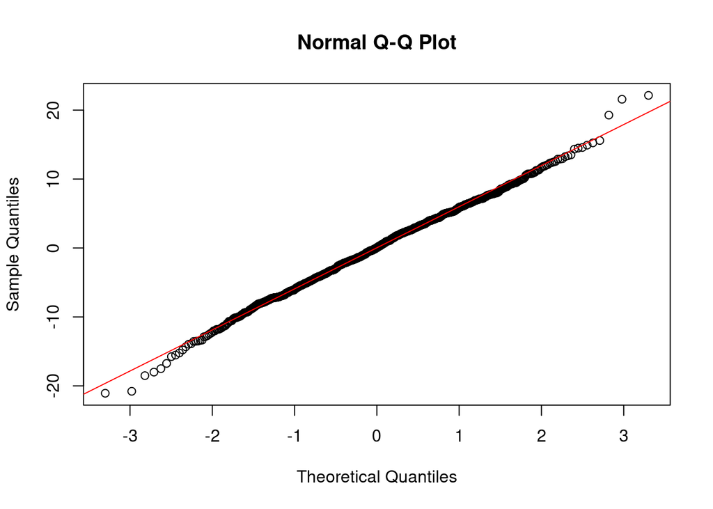

```r
qqnorm(residuals(model_A)); qqline(residuals(model_A), col = "red")
```

```r
# 2) Homocedasticidade
lmtest::bptest(model_A)
```

```
##
##  studentized Breusch-Pagan test
##
## data:  model_A
## BP = 16.952, df = 16, p-value = 0.3887
```

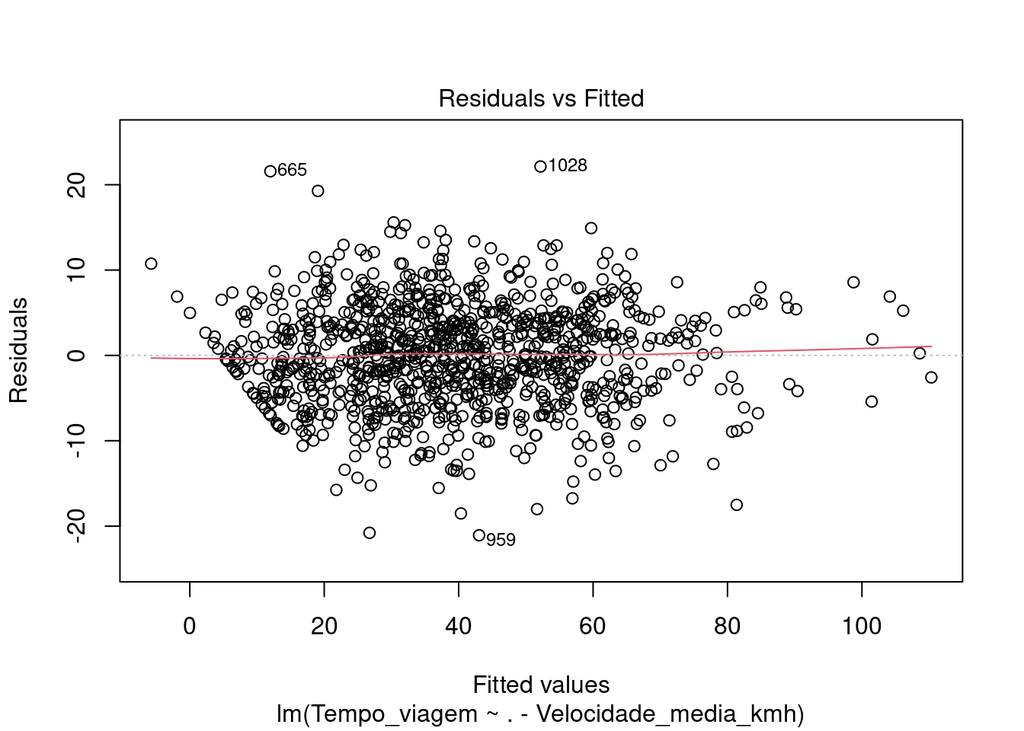

```r
plot(model_A, which = 1)   # resíduos vs fitted
```

```r
# 3) Autocorrelação
lmtest::dwtest(model_A)
```

```
##
##  Durbin-Watson test
##
## data:  model_A
## DW = 1.9367, p-value = 0.153
## alternative hypothesis: true autocorrelation is greater than 0
```

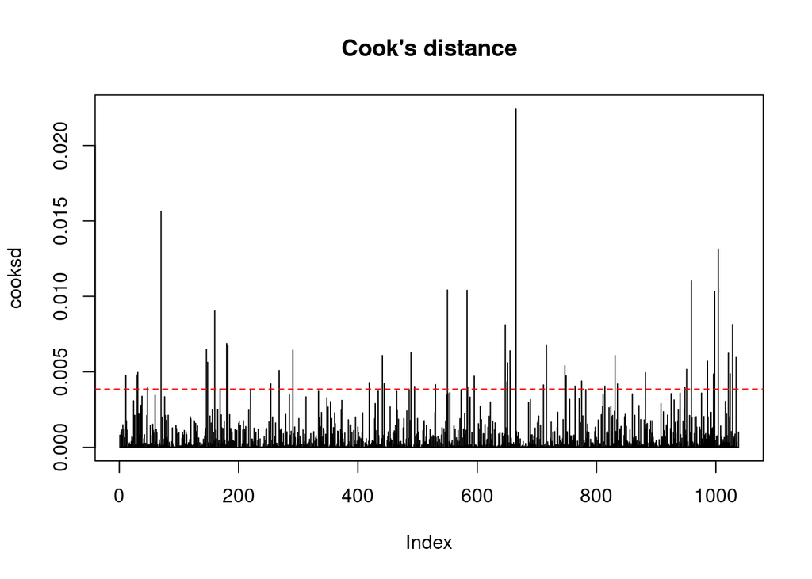

```r
# 4) Influência e outliers
cooksd <- cooks.distance(model_A)
plot(cooksd, type = "h", main = "Cook's distance")
abline(h = 4/length(cooksd), col = "red", lty = 2)
```

```r
which(cooksd > 4/length(cooksd))   # índices influentes
```

```
##   11   30   31   47   70  146  148  160  169  180  182  254  268  291  419  441
##   11   30   31   47   70  146  148  160  169  180  182  254  268  291  419  441
##  444  489  495  530  550  583  584  595  647  650  651  655  656  665  711  716
##  444  489  495  530  550  583  584  595  647  650  651  655  656  665  711  716
##  747  749  764  775  814  831  835  882  948  951  959  986  996  998 1004 1021
##  747  749  764  775  814  831  835  882  948  951  959  986  996  998 1004 1021
## 1024 1028 1034
## 1024 1028 1034
```

```r
# 5) Multicolinearidade final
car::vif(model_A)
```

```
##                            GVIF Df GVIF^(1/(2*Df))
## Distancia_km           1.707802  1        1.306829
## Congestionamento       3.143144  1        1.772891
## Hora_pico              2.423610  1        1.556795
## Tipo_transporte        3.323692  3        1.221622
## Paradas_intermediarias 1.964906  1        1.401751
## Chuva_mm               1.012472  1        1.006217
## Dia_semana             1.378430  6        1.027106
## Ocorrencia_acidente    1.056552  1        1.027887
## Tempo_espera           4.476338  1        2.115736
```

```r
performance::check_collinearity(model_A)
```

```
## # Check for Multicollinearity
##
## Low Correlation
##
##                    Term  VIF   VIF 95% CI adj. VIF Tolerance Tolerance 95% CI
##            Distancia_km 1.71 [1.58, 1.87]     1.31      0.59     [0.54, 0.63]
##        Congestionamento 3.14 [2.85, 3.48]     1.77      0.32     [0.29, 0.35]
##               Hora_pico 2.42 [2.21, 2.67]     1.56      0.41     [0.37, 0.45]
##         Tipo_transporte 3.32 [3.01, 3.69]     1.82      0.30     [0.27, 0.33]
##  Paradas_intermediarias 1.96 [1.80, 2.16]     1.40      0.51     [0.46, 0.55]
##                Chuva_mm 1.01 [1.00, 2.68]     1.01      0.99     [0.37, 1.00]
##              Dia_semana 1.38 [1.29, 1.50]     1.17      0.73     [0.67, 0.78]
##     Ocorrencia_acidente 1.06 [1.02, 1.18]     1.03      0.95     [0.85, 0.98]
##            Tempo_espera 4.48 [4.03, 4.99]     2.12      0.22     [0.20, 0.25]
```

### **7.2 Tratamento / alternativas quando há violações**

Caso alguma suposição não fosse atendida, as estratégias possíveis são:

#### **7.2.1 Observações influentes:**

Inspecionar manualmente (erros de entrada vs casos reais). Se forem entradas erradas, corrigir ou remover; se forem casos reais extremos, considerar modelagem robusta ou reportar análise de sensibilidade (fazer e apresentar resultados com e sem influentes).

```r
# Exemplo de reestimação sem observações influentes (já realizada)
influential <- which(cooks.distance(model_A) > 4/length(cooks.distance(model_A)))
model_noinf <- lm(formula(model_A), data = dados_final[-influential, ])
summary(model_noinf)
```

```
##
## Call:
## lm(formula = formula(model_A), data = dados_final[-influential,
##     ])
##
## Residuals:
##      Min       1Q   Median       3Q      Max
## -14.4212  -3.7355   0.0606   3.8960  14.3561
##
## Coefficients:
##                          Estimate Std. Error t value Pr(>|t|)
## (Intercept)             -10.75890    0.96751 -11.120  < 2e-16 ***
## Distancia_km              2.02546    0.04732  42.800  < 2e-16 ***
## Congestionamento          4.62855    0.16208  28.556  < 2e-16 ***
## Hora_picoSim              4.82007    0.52891   9.113  < 2e-16 ***
## Tipo_transporteCarroApp  -5.99094    0.81922  -7.313 5.46e-13 ***
## Tipo_transporteMetrô     -7.55730    0.69514 -10.872  < 2e-16 ***
## Tipo_transporteÔnibus    -2.22327    0.91876  -2.420 0.015709 *
## Paradas_intermediarias    0.85440    0.08343  10.241  < 2e-16 ***
## Chuva_mm                  0.03837    0.05790   0.663 0.507676
## Dia_semanaQua             3.17130    0.89027   3.562 0.000386 ***
## Dia_semanaQui             2.49671    0.87541   2.852 0.004436 **
## Dia_semanaSab            -0.64024    1.04220  -0.614 0.539151
## Dia_semanaSeg             2.68139    0.87737   3.056 0.002303 **
## Dia_semanaSex             5.25797    0.92100   5.709 1.51e-08 ***
## Dia_semanaTer             3.44074    0.87397   3.937 8.84e-05 ***
## Ocorrencia_acidenteSim   11.11881    0.69187  16.071  < 2e-16 ***
## Tempo_espera              1.06194    0.08732  12.161  < 2e-16 ***
## ---
## Signif. codes:  0 '***' 0.001 '**' 0.01 '*' 0.05 '.' 0.1 ' ' 1
##
## Residual standard error: 5.212 on 970 degrees of freedom
## Multiple R-squared:  0.9279, Adjusted R-squared:  0.9268
## F-statistic: 780.7 on 16 and 970 DF,  p-value: < 2.2e-16
```

```r
AIC(model_A, model_noinf)
```

```
##             df      AIC
## model_A     18 6679.175
## model_noinf 18 6078.946
```

#### **7.2.2 Heterocedasticidade:**

Usar erros padrão robustos (sandwich) ou transformar a variável resposta (log).

```r
# Erros padrão robustos (HC3)
library(sandwich); library(lmtest)
coeftest(model_noinf, vcov = sandwich::vcovHC(model_noinf, type = "HC3"))
```

```
##
## t test of coefficients:
##
##                           Estimate Std. Error  t value  Pr(>|t|)
## (Intercept)             -10.758899   0.875063 -12.2950 < 2.2e-16 ***
## Distancia_km              2.025459   0.045094  44.9166 < 2.2e-16 ***
## Congestionamento          4.628545   0.159294  29.0567 < 2.2e-16 ***
## Hora_picoSim              4.820067   0.523582   9.2059 < 2.2e-16 ***
## Tipo_transporteCarroApp  -5.990945   0.819004  -7.3149 5.390e-13 ***
## Tipo_transporteMetrô     -7.557301   0.687624 -10.9904 < 2.2e-16 ***
## Tipo_transporteÔnibus    -2.223267   0.958818  -2.3188 0.0206152 *
## Paradas_intermediarias    0.854396   0.081519  10.4810 < 2.2e-16 ***
## Chuva_mm                  0.038373   0.055550   0.6908 0.4898664
## Dia_semanaQua             3.171296   0.800597   3.9612 8.004e-05 ***
## Dia_semanaQui             2.496714   0.778508   3.2070 0.0013849 **
## Dia_semanaSab            -0.640237   0.896382  -0.7142 0.4752469
## Dia_semanaSeg             2.681387   0.757692   3.5389 0.0004209 ***
## Dia_semanaSex             5.257971   0.819308   6.4176 2.162e-10 ***
## Dia_semanaTer             3.440742   0.774631   4.4418 9.948e-06 ***
## Ocorrencia_acidenteSim   11.118812   0.646178  17.2070 < 2.2e-16 ***
## Tempo_espera              1.061942   0.087662  12.1141 < 2.2e-16 ***
## ---
## Signif. codes:  0 '***' 0.001 '**' 0.01 '*' 0.05 '.' 0.1 ' ' 1
```

```r
# Transformação log (opcional — cuidado na interpretação)
model_log <- lm(log(Tempo_viagem) ~ ., data = dados_final[-influential, c(all.vars(formula(model_A)))])
summary(model_log)
```

```
##
## Call:
## lm(formula = log(Tempo_viagem) ~ ., data = dados_final[-influential,
##     c(all.vars(formula(model_A)))])
##
## Residuals:
##      Min       1Q   Median       3Q      Max
## -1.12199 -0.11847  0.04177  0.18646  0.54810
##
## Coefficients:
##                          Estimate Std. Error t value Pr(>|t|)
## (Intercept)              2.160518   0.283929   7.609 6.52e-14 ***
## Distancia_km             0.055700   0.002593  21.479  < 2e-16 ***
## Velocidade_media_kmh    -0.006349   0.006265  -1.013  0.31114
## Congestionamento         0.130646   0.025558   5.112 3.84e-07 ***
## Hora_picoSim             0.129045   0.028994   4.451 9.55e-06 ***
## Tipo_transporteCarroApp -0.128740   0.044890  -2.868  0.00422 **
## Tipo_transporteMetrô    -0.272279   0.038091  -7.148 1.73e-12 ***
## Tipo_transporteÔnibus   -0.010328   0.050344  -0.205  0.83750
## Paradas_intermediarias   0.024720   0.004574   5.405 8.17e-08 ***
## Chuva_mm                 0.003191   0.003173   1.006  0.31483
## Dia_semanaQua            0.269811   0.048828   5.526 4.22e-08 ***
## Dia_semanaQui            0.238119   0.048022   4.959 8.38e-07 ***
## Dia_semanaSab            0.056202   0.057138   0.984  0.32555
## Dia_semanaSeg            0.229211   0.048116   4.764 2.19e-06 ***
## Dia_semanaSex            0.298153   0.050507   5.903 4.93e-09 ***
## Dia_semanaTer            0.267118   0.047928   5.573 3.24e-08 ***
## Ocorrencia_acidenteSim   0.180220   0.038116   4.728 2.60e-06 ***
## Tempo_espera             0.027153   0.004785   5.675 1.84e-08 ***
## ---
## Signif. codes:  0 '***' 0.001 '**' 0.01 '*' 0.05 '.' 0.1 ' ' 1
##
## Residual standard error: 0.2856 on 969 degrees of freedom
## Multiple R-squared:  0.7952, Adjusted R-squared:  0.7916
## F-statistic: 221.3 on 17 and 969 DF,  p-value: < 2.2e-16
```

#### **7.2.3 Resistência a outliers:**

Estimadores robustos (M-estimators) como `MASS::rlm.`

```r
library(MASS)
rlm_mod <- rlm(formula(model_A), data = dados_final[-influential, ])
summary(rlm_mod)
```

```
##
## Call: rlm(formula = formula(model_A), data = dados_final[-influential,
##     ])
## Residuals:
##       Min        1Q    Median        3Q       Max
## -14.55476  -3.76157   0.04006   3.77385  14.34828
##
## Coefficients:
##                         Value    Std. Error t value
## (Intercept)             -10.9553   1.0153   -10.7898
## Distancia_km              2.0192   0.0497    40.6567
## Congestionamento          4.6055   0.1701    27.0754
## Hora_picoSim              4.9242   0.5551     8.8715
## Tipo_transporteCarroApp  -5.8630   0.8597    -6.8197
## Tipo_transporteMetrô     -7.4160   0.7295   -10.1657
## Tipo_transporteÔnibus    -2.2855   0.9642    -2.3704
## Paradas_intermediarias    0.8912   0.0875    10.1789
## Chuva_mm                  0.0410   0.0608     0.6750
## Dia_semanaQua             3.2572   0.9343     3.4863
## Dia_semanaQui             2.3611   0.9187     2.5701
## Dia_semanaSab            -0.6616   1.0937    -0.6049
## Dia_semanaSeg             2.6516   0.9207     2.8798
## Dia_semanaSex             5.3765   0.9665     5.5627
## Dia_semanaTer             3.4744   0.9172     3.7882
## Ocorrencia_acidenteSim   11.0317   0.7261    15.1936
## Tempo_espera              1.0755   0.0916    11.7364
##
## Residual standard error: 5.589 on 970 degrees of freedom
```

```r
broom::tidy(model_noinf) %>% rename(lm_est = estimate) %>%
  left_join(broom::tidy(rlm_mod) %>% rename(rlm_est = estimate), by = "term")
```

```
## # A tibble: 17 × 8
##    term            lm_est std.error.x statistic.x   p.value  rlm_est std.error.y
##    <chr>            <dbl>       <dbl>       <dbl>     <dbl>    <dbl>       <dbl>
##  1 (Intercept)   -10.8         0.968      -11.1   4.02e- 27 -11.0         1.02
##  2 Distancia_km    2.03        0.0473      42.8   1.19e-225   2.02        0.0497
##  3 Congestionam…   4.63        0.162       28.6   1.16e-130   4.61        0.170
##  4 Hora_picoSim    4.82        0.529        9.11  4.48e- 19   4.92        0.555
##  5 Tipo_transpo…  -5.99        0.819       -7.31  5.46e- 13  -5.86        0.860
##  6 Tipo_transpo…  -7.56        0.695      -10.9   4.67e- 26  -7.42        0.730
##  7 Tipo_transpo…  -2.22        0.919       -2.42  1.57e-  2  -2.29        0.964
##  8 Paradas_inte…   0.854       0.0834      10.2   1.92e- 23   0.891       0.0875
##  9 Chuva_mm        0.0384      0.0579       0.663 5.08e-  1   0.0410      0.0608
## 10 Dia_semanaQua   3.17        0.890        3.56  3.86e-  4   3.26        0.934
## 11 Dia_semanaQui   2.50        0.875        2.85  4.44e-  3   2.36        0.919
## 12 Dia_semanaSab  -0.640       1.04        -0.614 5.39e-  1  -0.662       1.09
## 13 Dia_semanaSeg   2.68        0.877        3.06  2.30e-  3   2.65        0.921
## 14 Dia_semanaSex   5.26        0.921        5.71  1.51e-  8   5.38        0.967
## 15 Dia_semanaTer   3.44        0.874        3.94  8.84e-  5   3.47        0.917
## 16 Ocorrencia_a…  11.1         0.692       16.1   1.05e- 51  11.0         0.726
## 17 Tempo_espera    1.06        0.0873      12.2   9.03e- 32   1.08        0.0916
## # ℹ 1 more variable: statistic.y <dbl>
```

#### **7.2.4 Multicolinearidade persistente:**

considerar exclusão/combinação de variáveis redundantes, uso de componentes principais (PCR) ou penalização (ridge, lasso). Ex.: `glmnet::cv.glmnet()` para seleção penalizada.

## **8. Estimações e Predições**

Uma vez validado o modelo final, podemos utilizá-lo para realizar **estimações pontuais e intervalares** da média da variável resposta, bem como **predições** de novos valores individuais de tempo de viagem. Essa etapa é importante para avaliar, de forma prática, como o modelo pode ser aplicado em situáticas específicas.

### **8.1 Modelo final sem multicolinearidade**

Primeiro, vamos garantir que estamos usando o modelo correto (sem Velocidade_media_kmh):

```r
# Criar o modelo final sem Velocidade_media_kmh (Modelo A)
model_final <- lm(Tempo_viagem ~ Distancia_km + Congestionamento + Hora_pico +
                  Tipo_transporte + Paradas_intermediarias + Chuva_mm +
                  Dia_semana + Ocorrencia_acidente + Tempo_espera,
                data = dados_final)

# Verificar resumo do modelo
summary(model_final)
```

```
##
## Call:
## lm(formula = Tempo_viagem ~ Distancia_km + Congestionamento +
##     Hora_pico + Tipo_transporte + Paradas_intermediarias + Chuva_mm +
##     Dia_semana + Ocorrencia_acidente + Tempo_espera, data = dados_final)
##
## Residuals:
##      Min       1Q   Median       3Q      Max
## -21.0738  -3.9891   0.0366   4.0492  22.1338
##
## Coefficients:
##                         Estimate Std. Error t value Pr(>|t|)
## (Intercept)             -9.65952    1.05763  -9.133  < 2e-16 ***
## Distancia_km             2.01182    0.05273  38.156  < 2e-16 ***
## Congestionamento         4.54139    0.18032  25.186  < 2e-16 ***
## Hora_picoSim             4.99998    0.59017   8.472  < 2e-16 ***
## Tipo_transporteCarroApp -6.25223    0.91115  -6.862 1.18e-11 ***
## Tipo_transporteMetrô    -7.83974    0.76946 -10.189  < 2e-16 ***
## Tipo_transporteÔnibus   -2.54109    1.01975  -2.492  0.01287 *
## Paradas_intermediarias   0.80539    0.09359   8.605  < 2e-16 ***
## Chuva_mm                 0.04222    0.06353   0.665  0.50648
## Dia_semanaQua            2.62082    0.97366   2.692  0.00722 **
## Dia_semanaQui            2.20725    0.95975   2.300  0.02166 *
## Dia_semanaSab           -1.61609    1.14182  -1.415  0.15727
## Dia_semanaSeg            2.37288    0.96299   2.464  0.01390 *
## Dia_semanaSex            4.85143    1.01427   4.783 1.98e-06 ***
## Dia_semanaTer            2.82755    0.95593   2.958  0.00317 **
## Ocorrencia_acidenteSim  10.93577    0.73305  14.918  < 2e-16 ***
## Tempo_espera             1.07881    0.09663  11.164  < 2e-16 ***
## ---
## Signif. codes:  0 '***' 0.001 '**' 0.01 '*' 0.05 '.' 0.1 ' ' 1
##
## Residual standard error: 5.985 on 1021 degrees of freedom
## Multiple R-squared:  0.9056, Adjusted R-squared:  0.9042
## F-statistic: 612.4 on 16 and 1021 DF,  p-value: < 2.2e-16
```

### **8.2 Estimação de valores médios**

Para exemplificar, consideremos dois cenários distintos de viagem:

1. **Cenário A:** viagem de 10 km, congestionamento = 5, em horário de pico, utilizando **Ônibus**, com 2 paradas intermediárias, sem ocorrência de acidente, tempo de espera = 8 minutos, em uma **terça-feira**, sem chuva.
2. **Cenário B:** viagem de 5 km, congestionamento = 2, fora do horário de pico, utilizando **Metrô**, sem paradas intermediárias, sem acidente, tempo de espera = 3 minutos, em um **domingo**, sem chuva.

Para cada cenário, podemos obter a estimativa do tempo médio de viagem e o respectivo intervalo de confiança de 95%.

```r
# Cenário A
cenario_A <- data.frame(
  Distancia_km = 10,
  Congestionamento = 5,
  Hora_pico = "Sim",
  Tipo_transporte = "Ônibus",
  Paradas_intermediarias = 2,
  Chuva_mm = 0,
  Dia_semana = "Ter",
  Ocorrencia_acidente = "Não",
  Tempo_espera = 8
)

# Cenário B
cenario_B <- data.frame(
  Distancia_km = 5,
  Congestionamento = 2,
  Hora_pico = "Não",
  Tipo_transporte = "Metrô",
  Paradas_intermediarias = 0,
  Chuva_mm = 0,
  Dia_semana = "Dom",
  Ocorrencia_acidente = "Não",
  Tempo_espera = 3
)

# Estimações pontuais e intervalares
estimativa_A <- predict(model_final, newdata = cenario_A, interval = "confidence", level = 0.95)
estimativa_B <- predict(model_final, newdata = cenario_B, interval = "confidence", level = 0.95)

cat("Cenário A - Estimativa do tempo médio de viagem:\n")
```

```
## Cenário A - Estimativa do tempo médio de viagem:
```

```r
print(estimativa_A)
```

```
##        fit      lwr      upr
## 1 48.69328 46.86098 50.52557
```

```r
cat("\nCenário B - Estimativa do tempo médio de viagem:\n")
```

```
##
## Cenário B - Estimativa do tempo médio de viagem:
```

```r
print(estimativa_B)
```

```
##        fit      lwr      upr
## 1 4.879024 2.976303 6.781744
```

### **8.3 Predições de novas observações**

De forma análoga, podemos realizar predições individuais (incluindo o erro aleatório), obtendo intervalos de predição de 95% para novas viagens nos mesmos cenários:

```r
predicao_A <- predict(model_final, newdata = cenario_A, interval = "prediction", level = 0.95)
predicao_B <- predict(model_final, newdata = cenario_B, interval = "prediction", level = 0.95)

cat("Cenário A - Predição individual do tempo de viagem:\n")
```

```
## Cenário A - Predição individual do tempo de viagem:
```

```r
print(predicao_A)
```

```
##        fit      lwr      upr
## 1 48.69328 36.80632 60.58023
```

```r
cat("\nCenário B - Predição individual do tempo de viagem:\n")
```

```
##
## Cenário B - Predição individual do tempo de viagem:
```

```r
print(predicao_B)
```

```
##        fit       lwr      upr
## 1 4.879024 -7.018993 16.77704
```

### **8.4 Análise comparativa dos resultados

```r
# Criar resumo comparativo
resultados <- data.frame(
  Cenário = c("A (Ônibus, horário pico)", "B (Metrô, fora pico)"),
  Estimativa_Media = c(estimativa_A[1], estimativa_B[1]),
  IC_Inferior = c(estimativa_A[2], estimativa_B[2]),
  IC_Superior = c(estimativa_A[3], estimativa_B[3]),
  Predicao_Individual = c(predicao_A[1], predicao_B[1]),
  PI_Inferior = c(predicao_A[2], predicao_B[2]),
  PI_Superior = c(predicao_A[3], predicao_B[3])
)

print(resultados)
```

```
##                    Cenário Estimativa_Media IC_Inferior IC_Superior
## 1 A (Ônibus, horário pico)        48.693276   46.860980   50.525572
## 2     B (Metrô, fora pico)         4.879024    2.976303    6.781744
##   Predicao_Individual PI_Inferior PI_Superior
## 1           48.693276   36.806319    60.58023
## 2            4.879024   -7.018993    16.77704
```

### **8.4 Interpretação**

- No **Cenário A** (viagem longa, em horário de pico, de ônibus, com paradas e espera), o modelo prevê um tempo médio de viagem substancialmente elevado, com intervalo de confiança relativamente estreito. O intervalo de predição é mais amplo, refletindo a variabilidade natural entre viagens individuais.
- No **Cenário B** (viagem curta, fora do pico, de metrô, sem paradas e com pouca espera), o tempo estimado é consideravelmente menor, também com intervalo de confiança estreito e intervalo de predição mais amplo.

**Diferença chave entre os intervalos:**

- Intervalo de Confiança: estima a incerteza sobre a média do tempo de viagem para aquele cenário.
- Intervalo de Predição: estima a incerteza para uma viagem individual específica.

Esses resultados ilustram como o modelo pode ser usado tanto para prever a média esperada em cenários típicos quanto para prever a duração provável de uma viagem específica, sempre considerando a incerteza associada.

## **9. Conclusão**

Os diagnósticos do modelo indicaram bom ajuste e ausência de violações graves dos pressupostos da regressão múltipla.

Em síntese, a combinação entre distância, tráfego e horário de deslocamento explica de maneira satisfatória as variações no tempo de viagem. Tais resultados fornecem subsídios importantes para planejamento urbano e definição de políticas de mobilidade, especialmente na gestão do transporte em horários críticos.